# R for data science

JORGE GARCIA

2022-05-22

```r
# load data viz/analysis packages
library(tidyverse)
library(janitor)

# load math operations packages
library(PlaneGeometry)

# load animation paclages
library(gganimate)  # to create animations
library(gifski)     # to render animations
library(png)        # to save animations
```

## Import data

readr supports the following file formats with these read_*() functions:

- comma-separated values (CSV) files
- tab-separated values (TSV) files
- delimited files (CSV and TSV are important special cases)
- fixed-width files
- whitespace-separated files
- web log files

```r
censos_bolivia <- read_csv("data-raw/censos_bolivia.csv")

print(censos_bolivia)
```

```
## # A tibble: 4 × 4
##     Año `Población Total` `Población urbana` `Población rural`
##   <dbl>             <dbl>              <dbl>             <dbl>
## 1  1976           4613419            1906324           2707095
## 2  1992           6420792            3694846           2725946
## 3  2001           8274325            5165230           3109095
## 4  2012          10059856            6788962           3270894
```

## Tidy data - Variable Names

`rename()` function changes the names of individual variables using `new_name = old_name` syntax.

Best practices:

- Follow conventions (lower case, camel format, etc.).
- Avoid blank spaces.
- In English. (?)
- Short.

```r
censos_bolivia_tidy <- censos_bolivia %>%
  rename(year = Año,
         pob_total = `Población Total`,
         pob_urban = `Población urbana`,
         pob_rural = `Población rural`)
```

## Tidy data - Wide and Long Data

`pivot_longer()` “lengthens” data, increasing the number of rows and decreases the number of columns. The inverse transformation is `pivot_wider()`

Best practices:

- Reduce number of variables (to perform summaries with less code).
- Cleaning up data is often going from wide to long data.
- Each column should represent a variable, and each row should represent an observation an observation.

```r
censos_bolivia_tidy <- censos_bolivia %>%
  rename(year = Año,
         pob_total = `Población Total`,
         pob_urban = `Población urbana`,
         pob_rural = `Población rural`) %>%
  pivot_longer(cols = -year,
               names_to = "pob_type", # population type
               values_to = "value")

print(censos_bolivia_tidy)
```

```
## # A tibble: 12 × 3
##     year pob_type     value
##    <dbl> <chr>        <dbl>
##  1  1976 pob_total  4613419
##  2  1976 pob_urban  1906324
##  3  1976 pob_rural  2707095
##  4  1992 pob_total  6420792
##  5  1992 pob_urban  3694846
##  6  1992 pob_rural  2725946
##  7  2001 pob_total  8274325
##  8  2001 pob_urban  5165230
##  9  2001 pob_rural  3109095
## 10  2012 pob_total 10059856
## 11  2012 pob_urban  6788962
## 12  2012 pob_rural  3270894
```

## Tidy data - Recode Variables

`mutate()` adds new variables and preserves existing ones.

```r
censos_bolivia_tidy <- censos_bolivia %>%
  rename(year = Año,
         pob_total = `Población Total`,
         pob_urban = `Población urbana`,
         pob_rural = `Población rural`) %>%
  pivot_longer(cols = -year,
               names_to = "pob_type",
               values_to = "value") %>%
  mutate(pob_type = case_when(
    pob_type == "pob_total" ~ "total",
    pob_type == "pob_urban" ~ "urban",
    pob_type == "pob_rural" ~ "rural"
 ))
```

## Plotting Data

`ggplot()` initializes a ggplot object. It can be used to declare the input data frame for a graphic and to specify the set of plot aesthetics intended to be common throughout all subsequent layers unless specifically overridden

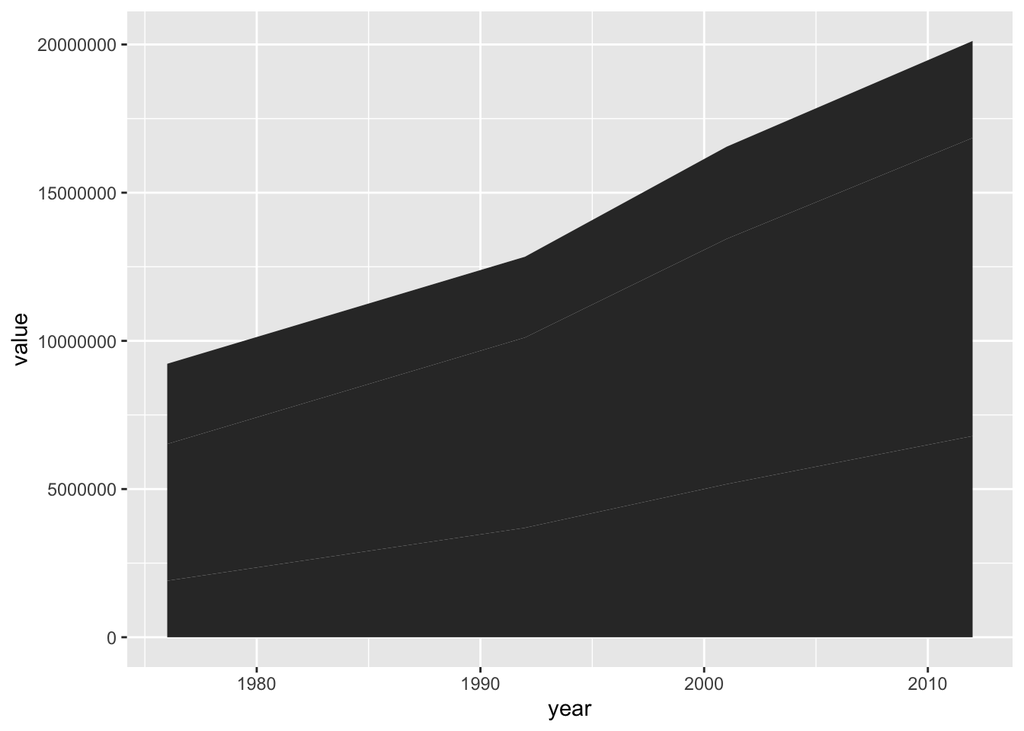

```r
censos_bolivia_tidy %>%
  ggplot(aes(
    x = year,
    y = value,
    group = pob_type,
    )) +
  geom_area() # geom_point, geom_area
```

### Customizing Plots - Color

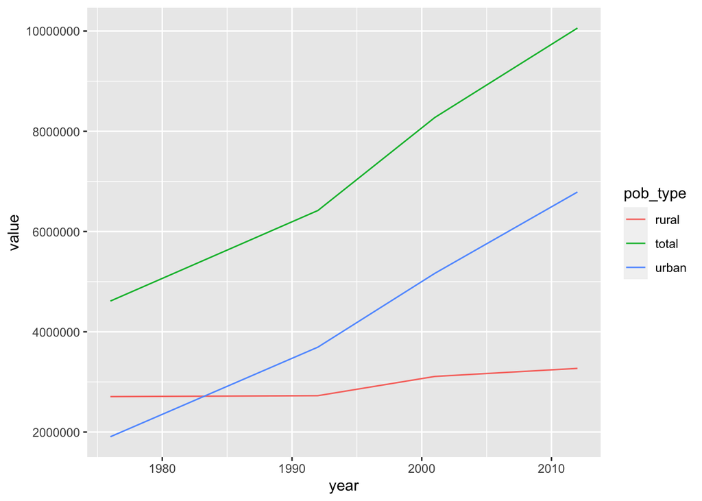

```r
censos_bolivia_tidy %>%
  ggplot(aes(
    x = year,
    y = value,
    group = pob_type,
    )) +
  geom_line(aes(
    color = pob_type
    ))
```

### Customizing Plots - Color HEX Values

`scale_manual` These functions allow you to specify your own set of mappings from levels in the data to aesthetic values.

- Also accepts HTML HEX value as input

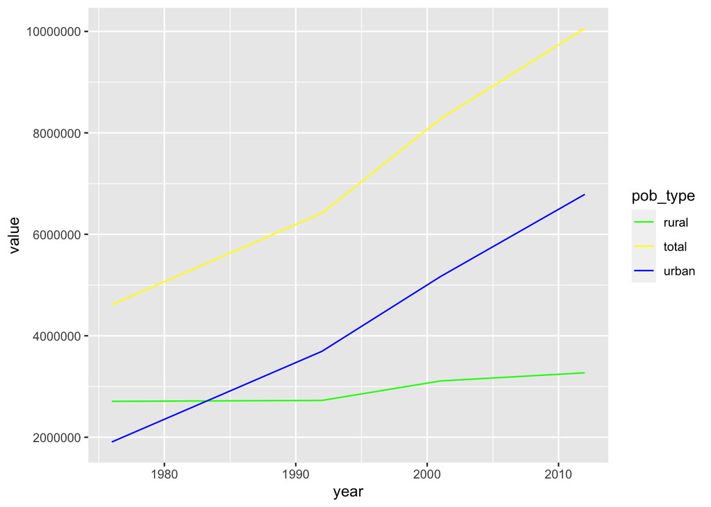

```r
censos_bolivia_tidy %>%
  ggplot(aes(
    x = year,
    y = value,
    group = pob_type,
    )) +
  geom_line(aes(color = pob_type)) +
  scale_color_manual(values = c("Green", "Yellow", "Blue"))
```

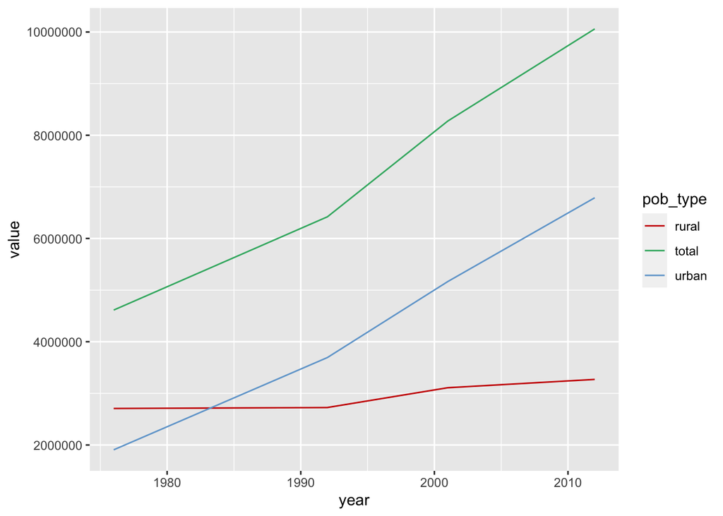

```r
censos_bolivia_tidy %>%
  ggplot(aes(
    x = year,
    y = value,
    group = pob_type,
    color = pob_type
    )) +
  geom_line() +
  scale_color_manual(values = c("#cc0000", "#3cb371", "#71a6d2"))
```

### Customizing Plots - Remove Default Gray Brackground and Customize

`theme_()` can be used if you just need to tweak the display of an existing theme. Themes are a powerful way to customize the non-data components of your plots.

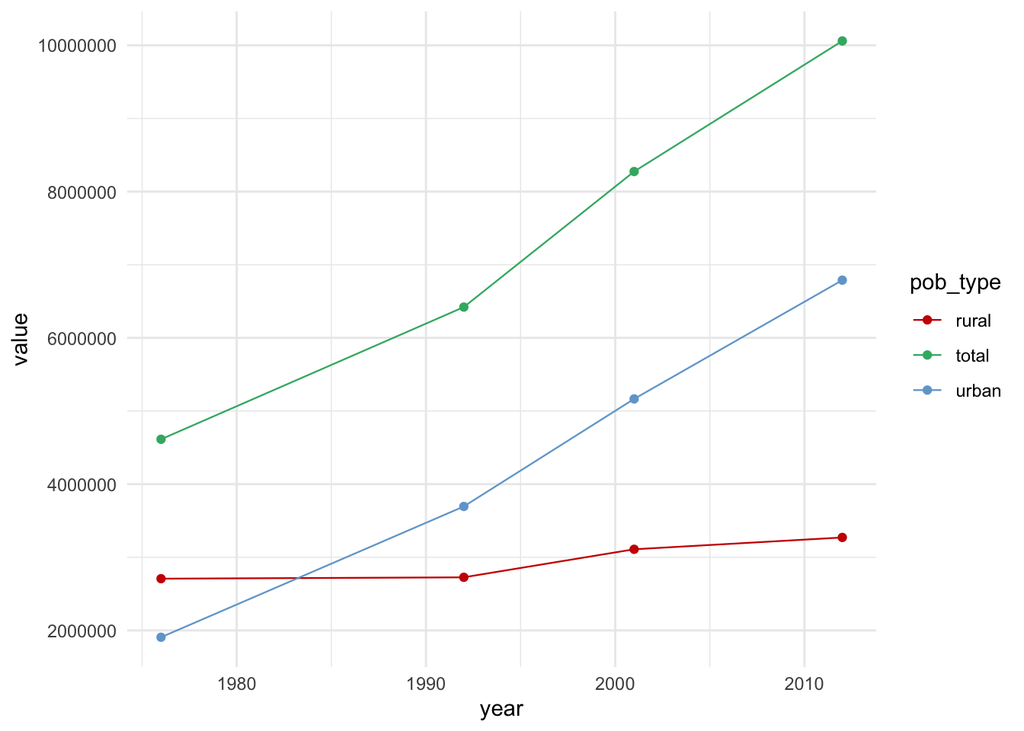

```r
censos_bolivia_tidy %>%
  ggplot(aes(
    x = year,
    y = value,
    group = pob_type,
    color = pob_type
    )) +
  geom_line(size = 0.4) +
  scale_color_manual(values = c("#cc0000", "#3cb371", "#71a6d2")) +
  theme_minimal()+
  geom_point()
```

### Customizing plots - Axis Titles

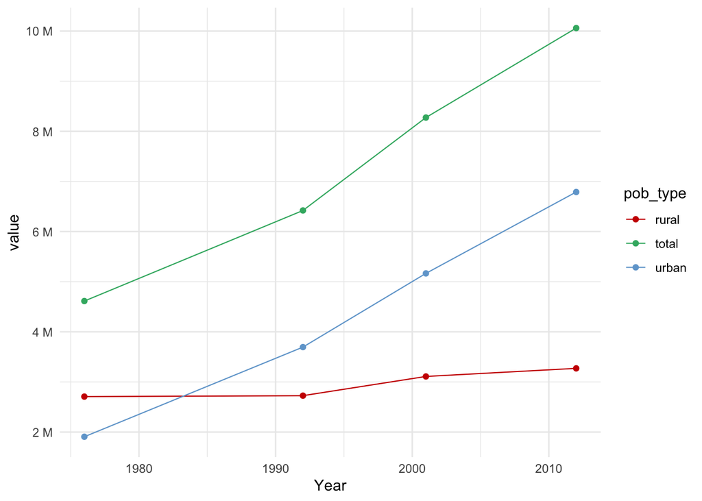

```r
censos_bolivia_tidy %>%
  ggplot(aes(
    x = year,
    y = value,
    group = pob_type,
    color = pob_type
    )) +
  geom_line(size = 0.4) +
  scale_color_manual(values = c("#cc0000", "#3cb371", "#71a6d2")) +
  theme_minimal() +
  geom_point() +
  scale_x_continuous(name = "Year") +
  scale_y_continuous(labels = scales::unit_format(unit = "M", scale = 1e-6))
```

### Customizing plots - Adding Labels

Best practices:

- Good labels are critical for making your plots accessible to a wider audience.
- Ensure the axis and legend labels display the full variable name.
- `labs()` function.

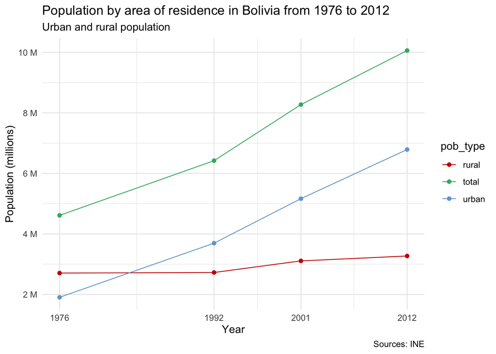

```r
censos_bolivia_tidy %>%
  ggplot(aes(
    x = year,
    y = value,
    group = pob_type,
    color = pob_type
    )) +
  geom_line(size = 0.4) +
  scale_color_manual(values = c("#cc0000", "#3cb371", "#71a6d2")) +
  theme_minimal() +
  geom_point() +
  scale_x_continuous(breaks = c(1976,1992,2001,2012)) +
  scale_y_continuous(labels = scales::unit_format(unit = "M"
                                                  , scale = 1e-6)) +
  labs(title = "Population by area of residence in Bolivia from 1976 to 2012",
       subtitle = "Urban and rural population",
       y = "Population (millions)",
       x = "Year",
       caption = "Sources: INE")
```

## Finding and Adding Insights

- `annotate()`
- Get insights from data available
- Year where Rural and Urban population intersect.
- create annotation layers with insights, passed in as vectors.
- Avoid adding columns or rows into the data frame.
- Accepts control characters `\r\n` `\r` and `\n`

### Intersection of Rural and Urban Populations

```r
# finding when urban population grows faster than rural
lineurban <- Line$new(A = c(1976, 1906324), B = c(1992, 3694846))
linerural <- Line$new(A = c(1976, 2707095), B = c(1992, 2725946))

intersectionLineLine(lineurban, linerural)
```

```
## [1]    1983.24 2715625.02
```

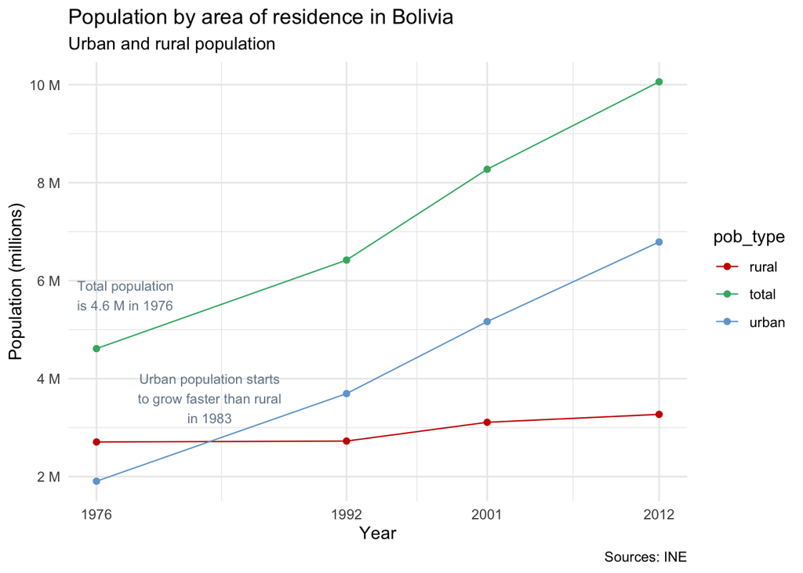

```r
censos_bolivia_tidy %>%
  ggplot(aes(
    x = year,
    y = value,
    group = pob_type,
    color = pob_type
    )) +
  geom_line(size = 0.4) +
  scale_color_manual(values = c("#cc0000", "#3cb371", "#71a6d2")) +
  theme_minimal() +
  geom_point() +
  scale_x_continuous(breaks = c(1976,1992,2001,2012)) +
  scale_y_continuous(labels = scales::unit_format(unit = "M"
                                                  , scale = 1e-6)) +
  labs(title = "Population by area of residence in Bolivia",
       subtitle = "Urban and rural population",
       y = "Population (millions)",
       x = "Year",
       caption = "Sources: INE") +
  # urban vs rural population comparison
  annotate("text",
          x = 1983.24,
          y = 3600000,
          size = 3,
          label = "Urban population starts\nto grow faster than rural\nin 1983",
          color = "#778899") +
  # total population since 1976
  annotate("text",
           x = 1976,
           y = 5700000,
           hjust = 0.2,
           size = 3,
           label = "Total population\nis 4.6 M in 1976",
           color = "#778899")
```

### Doubling of population with respect to 1976

Finding year where population doubles using total population in 1976 as reference.

```r
# Finding when population doubles
 4613419 * 2 # Hallar el valor de duplicacion
```

```
## [1] 9226838
```

```r
linetotal <- Line$new(A = c(1976, 4613419), B = c(2012, 10059856)) # Poblacion total
linedouble <- Line$new(A=c(1976, 9226838), B = c(2012, 9226838))  # Duplicacion

intersectionLineLine(linetotal, linedouble)
```

```
## [1]    2006.494 9226838.000
```

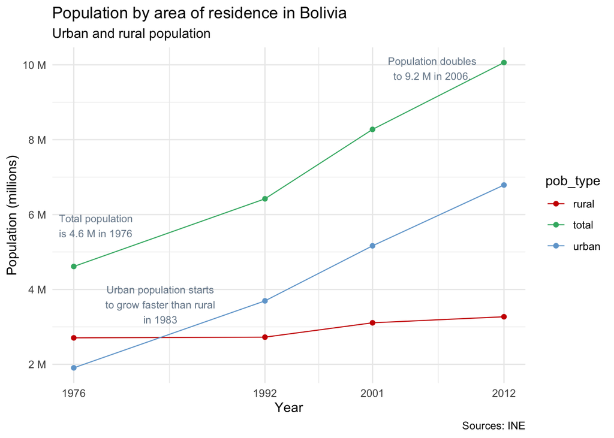

```r
censos_bolivia_tidy %>%
  ggplot(aes(
    x = year,
    y = value,
    group = pob_type,
    color = pob_type
    )) +
  geom_line(size = 0.4) +
  scale_color_manual(values = c("#cc0000", "#3cb371", "#71a6d2")) +
  theme_minimal() +
  geom_point() +
  scale_x_continuous(breaks = c(1976,1992,2001,2012)) +
  scale_y_continuous(labels = scales::unit_format(unit = "M"
                                                  , scale = 1e-6)) +
  labs(title = "Population by area of residence in Bolivia",
       subtitle = "Urban and rural population",
       y = "Population (millions)",
       x = "Year",
       caption = "Sources: INE") +
  # urban vs rural population comparison
  annotate("text",
          x = 1983.24,
          y = 3600000,
          #hjust = 0,
          size = 3,
          label = "Urban population starts\nto grow faster than rural\nin 1983",
          color = "#778899") +
  # total population since 1976
  annotate("text",
           x = 1976,
           y = 5700000,
           hjust = 0.2,
           size = 3,
           label = "Total population\nis 4.6 M in 1976",
           color = "#778899") +
  # total population doubles in 2006
  annotate("text",
           x = 2006,
           y = 9900000,
           size = 3,
           color = "#778899",
           label = "Population doubles\nto 9.2 M in 2006.")
```

## Animations

`gganimate()` A Grammar of Animated Graphics that helps create static visualizations compatible with ggplot, to specify transitions and animations.

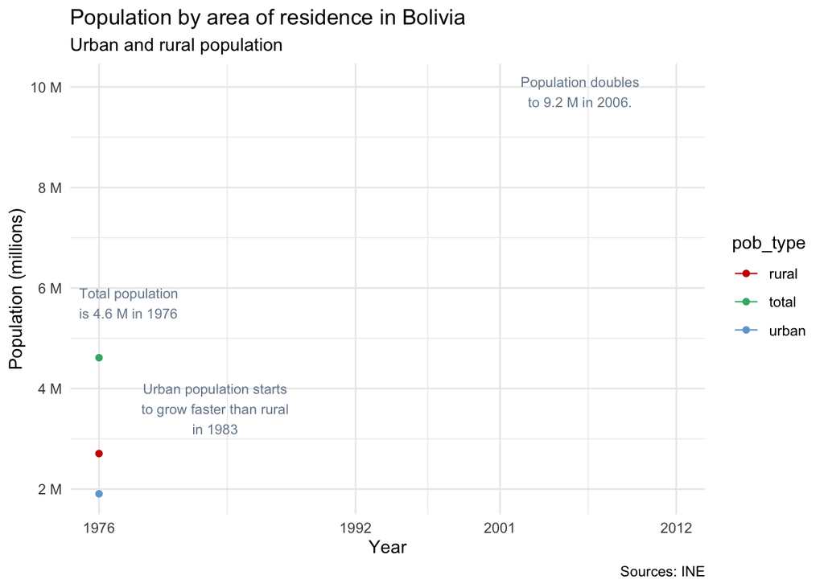

```r
censos_bolivia_tidy_gif <- censos_bolivia_tidy %>%
  ggplot(aes(
    x = year,
    y = value,
    group = pob_type,
    color = pob_type
  )) +
  geom_line(size = 0.4) +
  scale_color_manual(values = c("#cc0000", "#3cb371", "#71a6d2")) +
  theme_minimal() +
  geom_point() +
  scale_x_continuous(breaks = c(1976,1992,2001,2012)) +
  scale_y_continuous(labels = scales::unit_format(unit = "M"
                                                  , scale = 1e-6)) +
  labs(title = "Population by area of residence in Bolivia",
       subtitle = "Urban and rural population",
       y = "Population (millions)",
       x = "Year",
       caption = "Sources: INE") +
  # urban vs rural population comparison
  annotate("text",
           x = 1983.24,
           y = 3600000,
           #hjust = 0,
           size = 3,
           label = "Urban population starts\nto grow faster than rural\nin 1983",
           color = "#778899") +
  # total population since 1976
  annotate("text",
           x = 1976,
           y = 5700000,
           hjust = 0.2,
           size = 3,
           label = "Total population\nis 4.6 M in 1976",
           color = "#778899") +
  # total population doubles in 2006
  annotate("text",
           x = 2006,
           y = 9900000,
           size = 3,
           color = "#778899",
           label = "Population doubles\nto 9.2 M in 2006.") +
  transition_reveal(year) # <- line of code to create animations

censos_bolivia_tidy_gif
```